# Income Differences Across Education Levels

Dawson Raynes

## Question

How does the percentage of people earning above $50K differ across education levels and sex categories?

## Data

**Fairness dataset:** Adult Income Dataset, originally from the UCI Machine Learning Repository.

- Each row represents one person.
- My Fairness file contains 5,000 rows.
- The dataset includes information about education, sex, and income.

**Sports dataset:** 2023 Boston Marathon Runners Dataset, published by the SCORE Network.

- Each row represents one runner who completed the marathon.
- My Sports file contains 26,598 rows.

## Income rates above $50K are higher for men overall

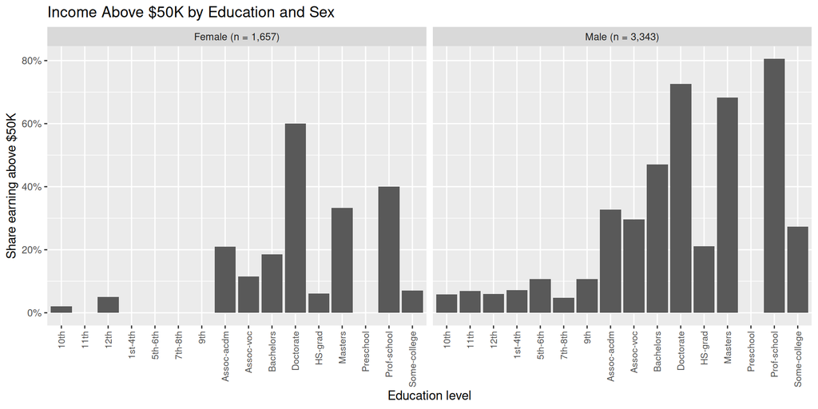

Figure 1

## What it shows, and its limits

- The percentage earning above $50K varies across education levels and between sex categories.
- I used fixed scales so readers can compare percentages directly between panels.
- Some groups contain very few observations. For example, the female preschool group contains only one person, so its percentage may not be representative.
- The dataset shows differences between groups, but it cannot establish that education or sex causes those income differences.

## Sources and AI use

Becker, B. & Kohavi, R. (1996). *Adult* [Dataset]. UCI Machine Learning Repository. https://doi.org/10.24432/C5XW20

Fay, J., Dykstra, A. J., & Ramler, I. (2023, June 27). *2023 Boston Marathon runners* [Dataset]. SCORE Network. https://data.scorenetwork.org/data/boston_marathon_2023.csv

**AI use:** None.